# Penanganan Autokorelasi Metode Cochrane-Orcutt dan Metode Hildreth-Lu (Soal Tugas Praktikum 2 No 1)

# Load Data

```r
library(readxl)
data <- read_xlsx("C:\\Users\\LENOVO\\Downloads\\data_market_share_price.xlsx")
data
```

```
## # A tibble: 20 × 3
##    Period `Market share` Price
##     <dbl>          <dbl> <dbl>
##  1      1           3.63  0.97
##  2      2           4.2   0.95
##  3      3           3.33  0.99
##  4      4           4.54  0.91
##  5      5           2.89  0.98
##  6      6           4.87  0.9
##  7      7           4.9   0.89
##  8      8           5.29  0.86
##  9      9           6.18  0.85
## 10     10           7.2   0.82
## 11     11           7.25  0.79
## 12     12           6.09  0.83
## 13     13           6.8   0.81
## 14     14           8.65  0.77
## 15     15           8.43  0.76
## 16     16           8.29  0.8
## 17     17           7.18  0.83
## 18     18           7.9   0.79
## 19     19           8.45  0.76
## 20     20           8.23  0.78
```

```r
library(dplyr)
library(TTR)
library(forecast)
library(lmtest) #digunakan untuk uji formal pendeteksian autokorelasi
library(orcutt) #untuk membuat model regresi Cochrane-Orcutt
library(HoRM) #untuk membuat model regresi Hildreth-Lu
model <- lm(`Price` ~ `Market share`, data = data)
summary(model)
```

```
##
## Call:
## lm(formula = Price ~ `Market share`, data = data)
##
## Residuals:
##       Min        1Q    Median        3Q       Max
## -0.028221 -0.009064 -0.002785  0.013958  0.029252
##
## Coefficients:
##                 Estimate Std. Error t value Pr(>|t|)
## (Intercept)     1.095363   0.013561   80.78  < 2e-16 ***
## `Market share` -0.039157   0.002092  -18.72 3.02e-13 ***
## ---
## Signif. codes:  0 '***' 0.001 '**' 0.01 '*' 0.05 '.' 0.1 ' ' 1
##
## Residual standard error: 0.01721 on 18 degrees of freedom
## Multiple R-squared:  0.9511, Adjusted R-squared:  0.9484
## F-statistic: 350.3 on 1 and 18 DF,  p-value: 3.019e-13
```

# Pengujian Asumsi

```r
library(lmtest)
dwtest(model)
```

```
##
##  Durbin-Watson test
##
## data:  model
## DW = 1.1513, p-value = 0.01099
## alternative hypothesis: true autocorrelation is greater than 0
```

Pada uji Durbin-Watson didapatkan nilai p-value sebesar 0.01099, karena nilai p-value < 0,05 maka tolak H0 sehingga data tersebut memiliki autokorelasi pada residualnya.

# Penanganan Autokorelasi

## Metode Cochrane-Orcutt

### Menggunakan library(orcutt)

```r
#Penanganan Autokorelasi Cochrane-Orcutt
library(orcutt)
modelCO<-cochrane.orcutt(model)
modelCO
```

```
## Cochrane-orcutt estimation for first order autocorrelation
##
## Call:
## lm(formula = Price ~ `Market share`, data = data)
##
##  number of interaction: 7
##  rho 0.41031
##
## Durbin-Watson statistic
## (original):    1.15126 , p-value: 1.099e-02
## (transformed): 2.09351 , p-value: 5.266e-01
##
##  coefficients:
##    (Intercept) `Market share`
##       1.082996      -0.037451
```

Hasil keluaran model setelah dilakukan penanganan adalah sebagai berikut:
$$Price = 1.082996 - 0.037451 *
Market share$$

```r
summary(modelCO)
```

```
## Call:
## lm(formula = Price ~ `Market share`, data = data)
##
##                  Estimate Std. Error t value  Pr(>|t|)
## (Intercept)     1.0829961  0.0202656  53.440 < 2.2e-16 ***
## `Market share` -0.0374514  0.0029661 -12.627 4.601e-10 ***
## ---
## Signif. codes:  0 '***' 0.001 '**' 0.01 '*' 0.05 '.' 0.1 ' ' 1
##
## Residual standard error: 0.0156 on 17 degrees of freedom
## Multiple R-squared:  0.9036 ,  Adjusted R-squared:  0.898
## F-statistic: 159.4 on 1 and 17 DF,  p-value: < 4.601e-10
##
## Durbin-Watson statistic
## (original):    1.15126 , p-value: 1.099e-02
## (transformed): 2.09351 , p-value: 5.266e-01
```

Hasil pengujian menunjukkan bahwa setelah dilakukan transformasi, nilai statistik Durbin-Watson meningkat dari 1.15126 menjadi 2.09351, dengan p-value yang berubah dari 1.099e-02 menjadi 5.266e-01. Nilai p-value setelah transformasi lebih besar dari taraf signifikansi 5% (0,05), sehingga gagal tolak H₀. Sehingga, dapat disimpulkan bahwa tidak terdapat cukup bukti untuk menyatakan bahwa residual mengalami autokorelasi positif pada taraf signifikansi 5%.

Berdasarkan hasil tersebut, transformasi dilakukan untuk menangani masalah autokorelasi pada residual. Setelah transformasi, diperoleh nilai Durbin-Watson sebesar 2,09351 dengan p-value 5.266e-01, sehingga asumsi independensi residual dapat dianggap terpenuhi.

Selanjutnya akan dilakukan transformasi atau penanganan autokorelasi secara manual dengan syntax berikut ini.

### Transformasi Manual Metode Cochrane-Orcutt

```r
#Transformasi Manual
# Nilai rho
rho <- modelCO$rho

# Transformasi variabel dependen
Price_trans <- data$Price[-1] - rho * data$Price[-nrow(data)]

# Transformasi variabel independen
Marketshare_trans <- data$`Market share`[-1] - rho * data$`Market share`[-nrow(data)]

# Model hasil transformasi
modelCOmanual <- lm(
  Price_trans ~ Marketshare_trans)

summary(modelCOmanual)
```

```
##
## Call:
## lm(formula = Price_trans ~ Marketshare_trans)
##
## Residuals:
##       Min        1Q    Median        3Q       Max
## -0.024204 -0.010506 -0.002757  0.008285  0.030463
##
## Coefficients:
##                    Estimate Std. Error t value Pr(>|t|)
## (Intercept)        0.638632   0.011950   53.44  < 2e-16 ***
## Marketshare_trans -0.037451   0.002966  -12.63  4.6e-10 ***
## ---
## Signif. codes:  0 '***' 0.001 '**' 0.01 '*' 0.05 '.' 0.1 ' ' 1
##
## Residual standard error: 0.01558 on 17 degrees of freedom
## Multiple R-squared:  0.9036, Adjusted R-squared:  0.898
## F-statistic: 159.4 on 1 and 17 DF,  p-value: 4.601e-10
```

```r
# Koefisien hasil transformasi
coef_trans <- coefficients(modelCOmanual)

# Intersep kembali ke persamaan awal
b0 <- coef_trans[1] / (1 - rho)

# Koefisien variabel independen
b1  <- coef_trans[2]
b2  <- coef_trans[3]

# Menampilkan persamaan regresi
cat(
  "Y = ", round(b0,6),
  " + ", round(b1,6),  "(Period)",
  sep = ""
)
```

```
## Y = 1.082996 + -0.037451(Period)
```

Menghasilkan persamaan yang sama dengan modelCO pada library(orcutt).

### Cek Autokorelasi

```r
#Deteksi autokorelasi
lmtest::dwtest(modelCO, alternative = 'two.sided')
```

```
##
##  Durbin-Watson test
##
## data:  modelCO
## DW = 2.0935, p-value = 0.9468
## alternative hypothesis: true autocorrelation is not 0
```

p-value = 0.9468 > 0,05. maka tidak ada autokorelasi dalam tingkat kepercayaan 5%. Maka, metode Cochrane-Orcutt mampu mengatasi permasalahan autokorelasi.

## Metode Hildreth-Lu

```r
# FUNGSI HILDRETH-LU

hildreth.lu.func <- function(r, model) {

  # Matriks X tanpa intercept
  X <- model.matrix(model)[, -1, drop = FALSE]

  # Variabel Y
  Y <- model.response(model.frame(model))

  # Jumlah observasi
  n <- length(Y)

  # Transformasi
  Y_trans <- Y[2:n] - r * Y[1:(n-1)]

  X_trans <- X[2:n, ] - r * X[1:(n-1), ]

  # Data hasil transformasi
  data_trans <- data.frame(
    Y_trans,
    X_trans
  )

  # Model hasil transformasi
  lm(Y_trans ~ ., data = data_trans)
}
```

```r
rho_grid <- seq(0.1, 1, by = 0.01)

tab <- data.frame(
  rho = rho_grid,
  SSE = sapply(rho_grid, function(r) {
    deviance(hildreth.lu.func(r, model))
  })
)

# Menampilkan rho dengan SSE minimum
tab[which.min(tab$SSE), ]
```

```
##     rho         SSE
## 32 0.41 0.004128764
```

Pertama-tama akan dicari di mana kira-kira ρ yang menghasilkan SSE minimum. Pada hasil di atas terlihat ρ minimum ketika 0.41. Namun, hasil tersebut masih kurang teliti sehingga akan dicari kembali ρ yang lebih optimum dengan ketelitian yang lebih. Jika sebelumnya jarak antar ρ yang dicari adalah 0.01, kali ini jarak antar ρ adalah 0.00001 dan dilakukan pada selang 0.3 sampai dengan 0,5.

```r
rho_grid2 <- seq(0.30, 0.50, by = 0.00001)

tab2 <- data.frame(
  rho = rho_grid2,
  SSE = sapply(rho_grid2, function(r) {
    deviance(hildreth.lu.func(r, model))
  })
)

# rho optimum
idx_opt <- which.min(tab2$SSE)

rho_HL <- tab2$rho[idx_opt]
sse_HL <- tab2$SSE[idx_opt]

rho_HL
```

```
## [1] 0.41031
```

```r
sse_HL
```

```
## [1] 0.004128763
```

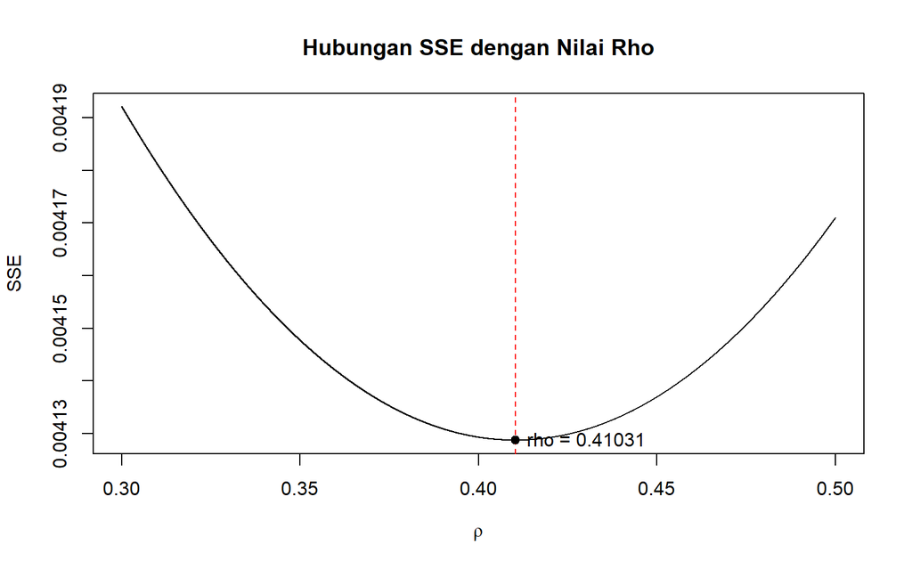

```r
plot(
  tab2$rho,
  tab2$SSE,
  type = "l",
  xlab = expression(rho),
  ylab = "SSE",
  main = "Hubungan SSE dengan Nilai Rho"
)

abline(
  v = rho_HL,
  lty = 2,
  col = "red"
)

points(
  rho_HL,
  sse_HL,
  pch = 19
)

text(
  rho_HL,
  sse_HL,
  labels = paste0("rho = ", round(rho_HL, 5)),
  pos = 4
)
```

Perhitungan yang dilakukan aplikasi R menunjukkan bahwa nilai ρ optimum, yaitu saat SSE terkecil terdapat pada nilai ρ=0.41031. Hal tersebut juga ditunjukkan pada plot. Selanjutnya, model dapat didapatkan dengan mengevaluasi nilai ρ ke dalam fungsi hildreth.lu.func, serta dilanjutkan dengan pengujian autokorelasi dengan uji Durbin-Watson. Namun, setelah pengecekan tersebut tidak lupa koefisien regresi tersebut digunakan untuk transformasi balik. Persamaan hasil transformasi itulah yang menjadi persamaan sesungguhnya.

```r
modelHL <- hildreth.lu.func(
  rho_HL,
  model
)

summary(modelHL)
```

```
##
## Call:
## lm(formula = Y_trans ~ ., data = data_trans)
##
## Residuals:
##       Min        1Q    Median        3Q       Max
## -0.024204 -0.010506 -0.002757  0.008285  0.030463
##
## Coefficients:
##              Estimate Std. Error t value Pr(>|t|)
## (Intercept)  0.638632   0.011950   53.44  < 2e-16 ***
## X_trans     -0.037451   0.002966  -12.63  4.6e-10 ***
## ---
## Signif. codes:  0 '***' 0.001 '**' 0.01 '*' 0.05 '.' 0.1 ' ' 1
##
## Residual standard error: 0.01558 on 17 degrees of freedom
## Multiple R-squared:  0.9036, Adjusted R-squared:  0.898
## F-statistic: 159.4 on 1 and 17 DF,  p-value: 4.601e-10
```

```r
# TRANSFORMASI BALIK HILDRETH-LU

coef_HL <- coef(modelHL)

b0_HL <- coef_HL[1] / (1 - rho_HL)
b1_HL <- coef_HL[2]
b2_HL <- coef_HL[3]

cat(
  "Price = ",
  round(b0_HL, 6),
  " + ", round(b1_HL, 6), "(Period)",
  sep = ""
)
```

```
## Price = 1.082996 + -0.037451(Period)
```

```r
#Deteksi autokorelasi
lmtest::dwtest(modelHL, alternative = 'two.sided')
```

```
##
##  Durbin-Watson test
##
## data:  modelHL
## DW = 2.0935, p-value = 0.9468
## alternative hypothesis: true autocorrelation is not 0
```

```r
#Perbandingan
# SSE
sseModelAwal <- deviance(model)
sseModelCO   <- deviance(modelCOmanual)
sseModelHL   <- deviance(modelHL)

# Banyak observasi
n <- nrow(data)

# MSE
mseModelAwal <- sseModelAwal / n
mseModelCO   <- sseModelCO / n
mseModelHL   <- sseModelHL / n

# Tabel perbandingan
akurasi <- matrix(
  c(
    sseModelAwal, sseModelCO, sseModelHL,
    mseModelAwal, mseModelCO, mseModelHL
  ),
  nrow = 2,
  byrow = TRUE
)

colnames(akurasi) <- c(
  "Model Awal",
  "Model Cochrane-Orcutt",
  "Model Hildreth-Lu"
)

rownames(akurasi) <- c("SSE", "MSE")

akurasi
```

```
##       Model Awal Model Cochrane-Orcutt Model Hildreth-Lu
## SSE 0.0053332267          0.0041287630      0.0041287630
## MSE 0.0002666613          0.0002064382      0.0002064382
```

Berdasarkan hasil tersebut dapat diketahui bahwa hasil penanganan autokorelasi dengan metode Cochrane-Orcutt dan Hildreth-Lu memiliki SSE yang sama, sebesar 0.0041287630 dan lebih baik dibandingkan model awal ketika autokorelasi masih terjadi, yaitu sebesar 0.0053332267.

# Simpulan

Autokorelasi yang terdapat pada data yang dianalisis terjadi akibat adanya korelasi di antara unsur penyusunnya. Adanya autokorelasi menyebabkan model regresi kurang baik karena akan meingkatkan galatnya. Autokorelasi dapat dideteksi secara eksploratif melalui uji formal Durbin-Watson. Kemudian, autokorelasi tersebut dapat ditangani dengan metode Cochrane-Orcutt dan Hildreth-Lu. Kedua metode menghasilkan nilai SSE yang sama dan lebih kecil dari model awalnya, artinya keduanya baik untuk digunakan.